# Paired-like factor classification

# 1 Goals

1. Compare sequence conservation across all homeodomain transcription factors.
2. Determine if there are residues specific to Paired-like homeodomains.

# 2 Define subclass families

## 2.1 Compile necessary data

1. Read in all sequence information associated with “homeobox” from [Uniprot](https://www.uniprot.org/) (mySequence). *344 TFs*
2. Grab list of all homeodomains from [CISBP](http://cisbp.ccbr.utoronto.ca/) and to ensure that we have all of the homeodomains from CISBP. CISBP also has a stronger curation than uniprot since it is based on DNA binding information instead of just sequence conservation. *229 TFs*
3. Import information on DNA binding domain location from [Uniprot](https://www.uniprot.org/).

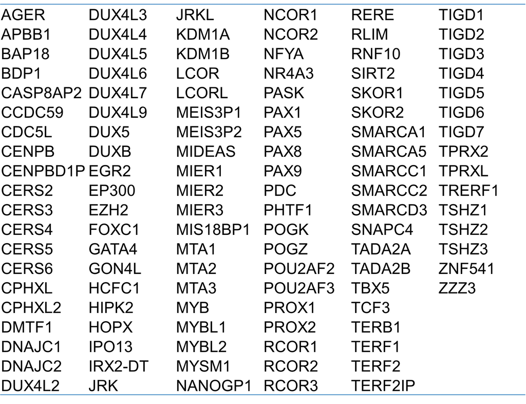

HDs not included in CISBP curation

**Note:** A manual entry has been added for the Drosophila Paired factor used in the Paired-dimer on DNA structure (1FJL). The S50Q mutation has been made to the entry!

```r
## Read in all entries of uniprot
mySequence <- readAAStringSet("All_HDs.fasta")

mySequence
```

```
## AAStringSet object of length 344:
##       width seq                                             names
##   [1]  2624 MFRRARLSVKPNVRPGVGARGS...GEATTVSEYFFNDIFIEVDETE sp|A6H8Y1|BDP1_HU...
##   [2]   301 MLLSPVTSTPFSVKDILRLERE...HGGQNATPQGHLAATLQGVRAW sp|A6NCS4|NKX26_H...
##   [3]   265 MESNLQGTFLLNNTPLAQFPEM...IRLLLRKHRAAFSVLSLGAHSV sp|A6NJ46|NKX63_H...
##   [4]   251 MSEKPKVYQGVRVKITVKELLQ...APSAAATSDFYKRETNCDICYS sp|A8K830|OCAT2_H...
##   [5]   251 MPSPRPRGSPPPAPSGSRVRPP...DEPSSSSIASIQSDDAESGVDG sp|A8MTQ0|NOTO_HU...
##   ...   ... ...
## [340]   525 MLGKRKRVVLTIKDKLDIIKKL...LVLRRLRTIIRKKQKIQNNKNH sp|Q4W5G0|TIGD2_H...
## [341]   339 MLPSAVAAHAGAYWDVVASSAL...QGALYLCSEEEAGSKGVLTGAV sp|Q6ZNG2|DBX2_HU...
## [342]   188 MHRARWLTPVIPALWEAEAGRS...KKKHMRWRSLCCQGWSRTPALK sp|Q7Z5D8|NANGN_H...
## [343]   591 MASKCSSERKSRTSLTLNQKLE...QPSTSRQDPPPAKRVRLTEGSD sp|Q96MW7|TIGD1_H...
## [344]   613 MTVTAFAAAMHRPFFNGYSTMQ...FPSPSKVNYTTMPPQPFYPSWY sp|P06601|PRD_DRO...
```

```r
## Read in all homeodomains from CISBP
HDlist <- read.delim("CISBP_HDs.csv",
                     sep = ",") %>%
  filter(Species == "Homo_sapiens")

head(HDlist)
```

```
##             ID    Name      Species          GeneID              Family
## 1 T075853_2.00    ZEB1 Homo_sapiens ENSG00000148516 C2H2 ZF,Homeodomain
## 2 T075854_2.00    ZEB2 Homo_sapiens ENSG00000169554 C2H2 ZF,Homeodomain
## 3 T075852_2.00   ZFHX3 Homo_sapiens ENSG00000140836 C2H2 ZF,Homeodomain
## 4 T167063_2.00    CUX1 Homo_sapiens ENSG00000257923     CUT,Homeodomain
## 5 T167057_2.00    CUX2 Homo_sapiens ENSG00000111249     CUT,Homeodomain
## 6 T167060_2.00 ONECUT1 Homo_sapiens ENSG00000169856     CUT,Homeodomain
##   Evidence
## 1        D
## 2        D
## 3        D
## 4        D
## 5        D
## 6        D
```

```r
HD <- HDlist$Name %>% gsub("\\.", "-", .)


## Read in DNA binding domain mapping information from Uniprot
DBDlist <- read_excel("DBD_information.xlsx") %>%
  dplyr::select(Gene_name, DBD_start, DBD_end)

head(DBDlist)
```

```
## # A tibble: 6 × 3
##   Gene_name DBD_start DBD_end
##   <chr>     <chr>     <chr>
## 1 BDP1      NA        NA
## 2 NKX2-6    132       191
## 3 NKX6-3    139       198
## 4 OCAT2     NA        NA
## 5 NOTO      156       215
## 6 LEUTX     33        67
```

**Combine all databases together.**

```r
df <- data.frame("TF_tmp" = names(mySequence),
                 "seq" = as.character(mySequence, use.names = FALSE)) %>%
  separate(TF_tmp, into = c("x1", "TF_tmp2"), sep = " GN=" ) %>%
  separate(TF_tmp2, into = c("TF"), sep = " ") %>%
  dplyr::select(-x1) %>%
  filter(TF %in% HD) %>%
  merge(., DBDlist, by.x = "TF", by.y = "Gene_name", all.x = TRUE)

df$DBD_start <- as.numeric(df$DBD_start)
df$DBD_end <- as.numeric(df$DBD_end)
```

*Sanity checks:*

1. Do all HDs have DNA binding domain starts and ends?
2. Check DNA binding domain lengths. Are they what we would expect?
3. If the DNA binding domain lengths are not the correct length, ensure that we have the proper homeodomain.

```r
df %>% filter(is.na(DBD_start))
```

```
##     TF
## 1 PAX2
##                                                                                                                                                                                                                                                                                                          …
## 1 MDMHCKADPFSAMHPGHGGVNQLGGVFVNGRPLPDVVRQRIVELAHQGVRPCDISRQLRV…
##   DBD_start DBD_end
## 1        NA      NA
```

```r
df %>% filter(is.na(DBD_end))
```

```
##     TF
## 1 PAX2
##                                                                                                                                                                                                                                                                                                          …
## 1 MDMHCKADPFSAMHPGHGGVNQLGGVFVNGRPLPDVVRQRIVELAHQGVRPCDISRQLRV…
##   DBD_start DBD_end
## 1        NA      NA
```

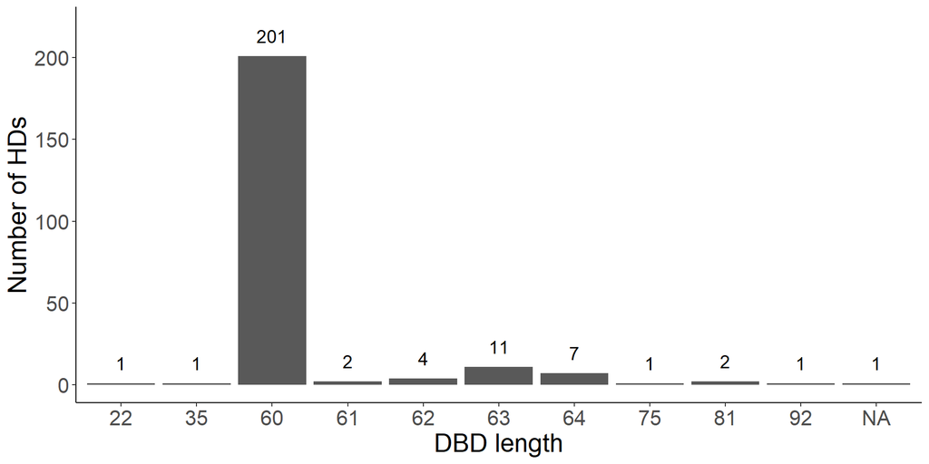

```r
df %>%
  mutate(DBD_length = DBD_end - DBD_start +1) %>%
  group_by(DBD_length) %>%
  summarise(Count = n()) %>%
  ggplot(aes(x = as.factor(DBD_length), y = Count, label = Count)) +
  geom_bar(stat = "identity") +
  geom_text(vjust = -1, size = 5) +
  xlab("DBD length") +
  ylab("Number of HDs") +
  theme_classic() +
  ylim(c(0, 220)) +
  theme(text = element_text(size = 20))
```

```r
df %>%
  mutate(length = DBD_end - DBD_start +1) %>%
  filter(! (length %in% c(60:64))) %>%
  dplyr::select(TF, length)
```

```
##       TF length
## 1 HMBOX1     75
## 2  HNF1A     81
## 3  HNF1B     81
## 4  LEUTX     35
## 5  NOBOX     92
## 6   PAX2     NA
## 7  TPRX1     22
```

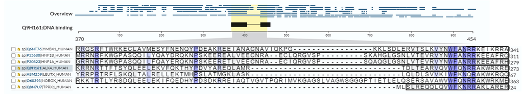

Conservation of atypical length homeodomains to ALX4

Most entries now have an homeobox-*like* DNA binding domain associated with them. These have been removed on this current version to accommodate the bit information part of this analysis!

## 2.2 DNA binding domain clustering

### 2.2.1 All class

```r
Family <- read_excel("Family_annotation.xlsx") %>% as.data.frame()
rownames(Family) <- Family$TF
Family <- dplyr::select(Family, -TF)

Family$TF = rownames(Family)

dfDBD <- df %>% mutate(seqDBD = subseq(seq, start = DBD_start, end = DBD_end)) %>%
  group_by(TF) %>%
  add_count() %>%
  arrange(DBD_start) %>%
  mutate(HDnum = row_number()) %>%
  mutate(TF = case_when(n > 1 ~ paste(TF, HDnum, sep = "_"),
                        TRUE ~ TF)) %>%
  dplyr::select(-c(n, HDnum)) %>%
  merge(., Family)
#filter(Class == "ANTP")


AA <- AAStringSet(dfDBD %>% .$seqDBD)
names(AA) <- dfDBD %>% .$TF

myAlignment <- msa(AA)
```

```
## use default substitution matrix
```

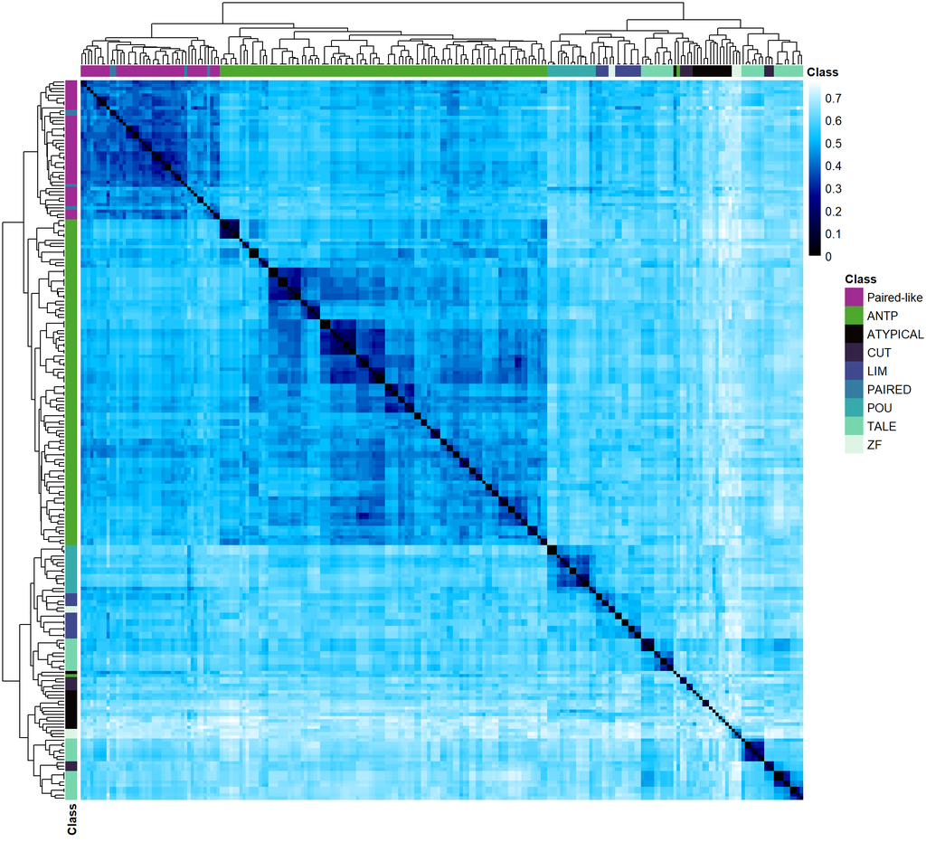

```r
myAlignment4tree <- msaConvert(myAlignment, type="seqinr::alignment")
distances <- dist.alignment(myAlignment4tree, "similarity", gap = TRUE)

anncolor = list(Class = c(`Paired-like`="#A02B93",
                          `ANTP`="#4EA72E",
                          `ATYPICAL`=mako(7)[1],
                          `CUT`=mako(7)[2],
                          `LIM`=mako(7)[3],
                          `PAIRED`=mako(7)[4],
                          `POU`=mako(7)[5],
                          `TALE`=mako(7)[6],
                          `ZF`=mako(7)[7]))

pheatmap(distances %>% as.matrix(),
         cluster_rows = TRUE,
         color = colorRampPalette(colors = c("black", "darkblue", "deepskyblue", "white"))(100),
         drop_levels = FALSE,
         show_rownames = FALSE,
         show_colnames = FALSE,
         annotation_row = Family %>% select(-TF, -Subclass),
         annotation_col = Family %>% select(-TF, -Subclass),
         width = 8,
         height = 7,
         method = "complete",
         angle_col = 90,
         border_color = NA,
         annotation_colors = anncolor,
         annotation_legend = TRUE)
```

### 2.2.2 Just Paired-like and ANTP

As the ANTP and Paired-like classes cluster together and these classes typically only have a single DNA binding domain, continue with only these classes.

Filter for 60 amino acid DNA binding domains

```r
dfDBD <- df %>% mutate(seqDBD = subseq(seq, start = DBD_start, end = DBD_end)) %>%
  group_by(TF) %>%
  add_count() %>%
  arrange(DBD_start) %>%
  mutate(HDnum = row_number()) %>%
  mutate(TF = case_when(n > 1 ~ paste(TF, HDnum, sep = "_"),
                        TRUE ~ TF)) %>%
  dplyr::select(-c(n, HDnum)) %>%
  merge(., Family) %>%
  filter(Class %in% c("ANTP", "Paired-like")) %>%
  filter(DBD_end - DBD_start == 59)


AA <- AAStringSet(dfDBD %>% filter(Class %in% c("ANTP", "Paired-like")) %>% .$seqDBD)
names(AA) <- dfDBD %>% filter(Class %in% c("ANTP", "Paired-like")) %>% .$TF

myAlignment <- msa(AA)
```

```
## use default substitution matrix
```

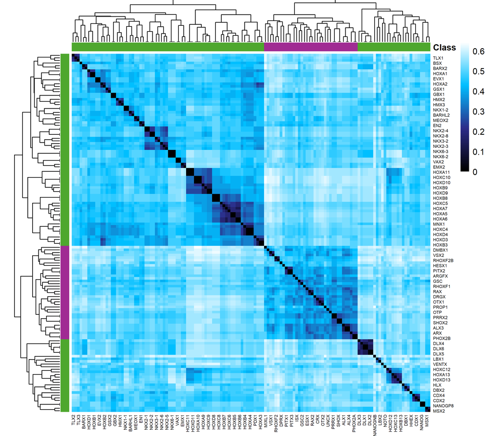

```r
myAlignment4tree <- msaConvert(myAlignment, type="seqinr::alignment")
distances <- dist.alignment(myAlignment4tree, "similarity", gap = TRUE)

tmp <- hclust(distances %>% as.dist())

annot_df <- data.frame(TF = tmp$labels,
                       Index = c(1:138)) %>%
  mutate(Class = case_when(Index %in% c(1:36) ~ "Paired-like",
                           TRUE ~ "ANTP")) %>%
  mutate(Class = factor(Class))

rownames(annot_df) <- annot_df$TF

annot_df <- annot_df %>% select(Class)

anncolor = list(Class = c(`Paired-like`="#A02B93", `ANTP`="#4EA72E"))


g <- pheatmap(distances %>% as.matrix(),
              cluster_rows = TRUE,
              color = colorRampPalette(colors = c("black", "#2D2D8A", "deepskyblue", "white"))(100),
              drop_levels = FALSE,
              show_rownames = TRUE,
              show_colnames = TRUE,
              width = 14,
              cellwidth = 5,
              cellheight = 5,
              border_color = NA,
              height = 12,
              filename = "DBD_heatmap.png",
              method = "complete",
              angle_col = 90,
              annotation = annot_df,
              annotation_row = annot_df,
              annotation_names_row = FALSE,
              annoation_names_col = FALSE,
              annotation_colors = anncolor,
              # annotation_legend = FALSE,
              legend = TRUE,
              fontsize_row = 5,
              fontsize_col = 5)

genesInHeatOrder_v <- g$tree_row$labels[g$tree_row$order]
Odd <- genesInHeatOrder_v[c(TRUE, FALSE)]
Even <- genesInHeatOrder_v[c(FALSE, TRUE)]

labs.row <- rownames(distances %>%
                       as.matrix())
labs.col <- colnames(distances %>%
                       as.matrix())

labs.row[labs.row %in% Odd] <- ""

labs.col[labs.col %in% Even] <- ""

pheatmap(distances %>% as.matrix(),
         cluster_rows = TRUE,
         color = colorRampPalette(colors = c("black", "#2D2D8A", "deepskyblue", "white"))(100),
         drop_levels = FALSE,
         show_rownames = TRUE,
         show_colnames = TRUE,
         width = 8,
         height = 7,
         cellwidth = 3,
         cellheight = 3,
         border_color = NA,
         method = "complete",
         angle_col = 90,
         annotation = annot_df,
         file = "DBD_heatmap.png",
         annotation_row = annot_df,
         annotation_names_row = FALSE,
         annoation_names_col = FALSE,
         annotation_colors = anncolor,
         annotation_legend = FALSE,
         legend = TRUE,
         fontsize_row = 5,
         fontsize_col = 5,
         labels_row = labs.row,
         labels_col = labs.col) %>% print()
```

### 2.2.3 Paired-like cladogram

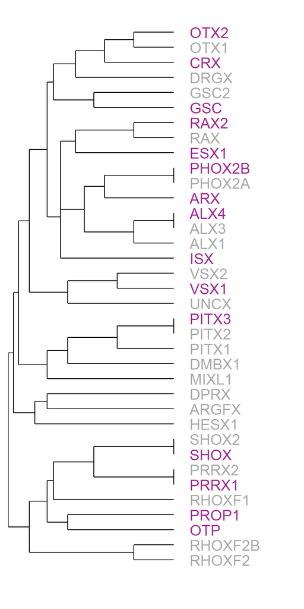

```r
flank = params$flank

Family$TF = rownames(Family)

dfDBD_PairedL <- df %>% mutate(seqDBD = subseq(seq, start = DBD_start, end = DBD_end)) %>%
  group_by(TF) %>%
  add_count() %>%
  arrange(DBD_start) %>%
  mutate(HDnum = row_number()) %>%
  mutate(TF = case_when(n > 1 ~ paste(TF, HDnum, sep = "_"),
                        TRUE ~ TF)) %>%
  dplyr::select(-c(n, HDnum)) %>%
  merge(., Family) %>%
  filter(Class == "Paired-like") %>%
  filter(DBD_end - DBD_start == 59)


AA <- AAStringSet(dfDBD_PairedL$seqDBD)
names(AA) <- dfDBD_PairedL$TF

myAlignment <- msa(AA)

myAlignment4tree <- msaConvert(myAlignment, type="seqinr::alignment")
distances <- dist.alignment(myAlignment4tree, "similarity", gap = TRUE)

tmp <- hclust(distances %>% as.dist())


tmp <- dendro_data(tmp, type = "rectangle")
tested <- c("PHOX2B", "ARX", "RAX2", "PROP1", "ALX4", "SHOX", "VSX1", "PRRX1", "GSC", "ESX1", "CRX", "OTP", "ISX", "OTX2", "PITX3")

tmp$labels$tested <- (tmp$labels$label %in% tested)

ggplot() +
  geom_segment(data = tmp$segments, aes(x = x, y = y, xend = xend, yend = yend)) +
  coord_flip() +
  scale_y_reverse(expand = expansion(mult = c(0,0.6))) +
  geom_text(data = tmp$labels,
            aes(x = x, y = y-0.05, label = label,
                color = tested), vjust = 0.5, size = 5, hjust = 0, show.legend = FALSE) +
  scale_color_manual(values = c("darkgray", "#A02B93")) +
  theme_dendro()
```

### 2.2.4 Family breakdown

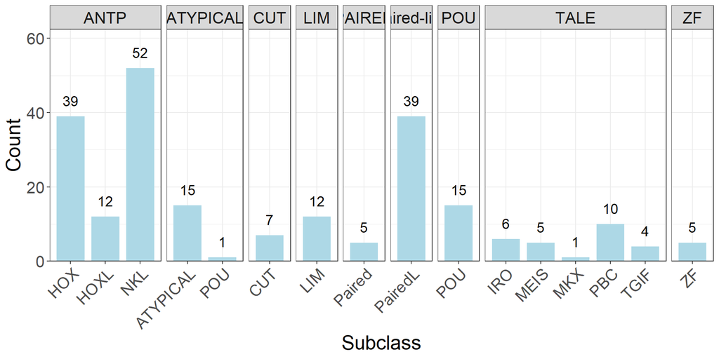

```r
Family %>%
  group_by(Class, Subclass) %>%
  summarise(Count = n()) %>%
  ggplot(aes(x = Subclass, y = Count, label = Count)) +
  geom_col(width = 0.8, fill = "lightblue") +
  facet_grid(~Class, scale = "free", space = "free") +
  theme_gray() +
  geom_text(vjust = -1, size = 5) +
  scale_y_continuous(expand = expansion(mult = c(0, 0.2))) +
  theme_bw() +
  theme(text = element_text(size = 20),
        axis.text.x = element_text(angle = 45, vjust = 1, hjust = 1))
```

# 3 Residue composition of classes

### 3.0.1 Define function to create sequence logos

```r
namespace <- matrix(data = c( "R",  "Basic",    "#255C99",
                              "H",  "Basic",    "#255C99",
                              "K",  "Basic",    "#255C99",
                              "D",  "Acidic",   "#D62839",
                              "E",  "Acidic",   "#D62839",
                              "S",  "Polar",    "#109648",
                              "T",  "Polar",    "#109648",
                              "N",  "Polar",    "#109648",
                              "Q",  "Polar",    "#109648",
                              "C",  "Special",  "#5E239D",
                              "G",  "Special",  "#5E239D",
                              "P",  "Special",  "#5E239D",
                              "A",  "Hydrophobic",  "#000000",
                              "V",  "Hydrophobic",  "#000000",
                              "I",  "Hydrophobic",  "#000000",
                              "L",  "Hydrophobic",  "#000000",
                              "M",  "Hydrophobic",  "#000000",
                              "F",  "Hydrophobic",  "#000000",
                              "Y",  "Hydrophobic",  "#000000",
                              "W",  "Hydrophobic",  "#000000",
                              "o", "Empty", "gray"),
                    ncol = 3, byrow = TRUE) %>%
  as.data.frame()

colnames(namespace) <- c("Residue", "Type", "Color")

col_scheme <- make_col_scheme(chars = namespace$Residue,
                              groups = namespace$Type,
                              cols = namespace$Color)


H <- data.frame(xmin = c(9.5, 27.5, 41.5),
                xmax = c(22.5, 37.5, 56.5),
                ymin = c(0,0,0),
                ymax = c(4.5,4.5,4.5))

DifferentialAlign2seq <- function(data, column, filter1, filter2 = NA, norm = TRUE, tile = FALSE) {

  lower_range = 0 %>% as.character()
  outer_range = 60 %>% as.character()

  group1 <- filter(data, !!rlang::sym(column) == filter1) %>%
    .$seqDBD %>%
    AAStringSet(.)

  plot1 <- ggplot() +
    geom_logo(group1 %>% as.data.frame(),
              stack_width = 0.75,
              namespace = namespace$Residue,
              col_scheme = col_scheme,
              seq_type = "other") +
    theme_logo() +
    theme(text = element_text(size = 32),
          legend.position = "none",
          plot.title = element_text(size = 28)) +
    scale_x_continuous(labels = seq(from = 5, by = 5, to = 60),
                       breaks = seq(from = 5, by = 5, to = 60),
                       expand = c(0,0),
                       limits = c(0.5, 60.5)) +
    ggtitle(paste(filter1, " (n = ", length(group1), ")", sep = "")) +
    geom_rect(data = H, aes(xmin = xmin, xmax = xmax, ymin = ymin, ymax = ymax),
              color = "lightgray",
              alpha = 0.1) +
    ylim(c(0,4.5))

  if (is.na(filter2)) {

    gridExtra::grid.arrange(plot1)

  }

  else {

    group2 <- data %>%
      filter(!!rlang::sym(column) == filter2) %>%
      .$seqDBD %>%
      AAStringSet(.)


    plot2 <- ggplot() +
      geom_logo(group2 %>% as.data.frame(),
                stack_width = 0.75,
                namespace = namespace$Residue,
                col_scheme = col_scheme,
                seq_type = "other") +
      theme_logo() +
      theme(text = element_text(size = 32),
            legend.position = "none") +
      scale_x_continuous(labels = seq(from = 2, by = 2, to = 60),
                         breaks = seq(from = 2, by = 2, to = 60),
                         expand = c(0,0),
                         limits = c(0.5, 60.5)) +
      ggtitle(paste(filter2, " (n = ", length(group2), ")", sep = "")) +
      geom_rect(data = H, aes(xmin = xmin, xmax = xmax, ymin = ymin, ymax = ymax),
                color = "lightgray",
                alpha = 0.1) +
      ylim(c(0,4.5))


    g1 <- geom_logo(group1 %>% as.data.frame(), plot = FALSE) %>%
      group_by(position, letter) %>%
      mutate(group = "GROUP1")

    g2 <- geom_logo(group2 %>% as.data.frame(), plot = FALSE) %>%
      group_by(position, letter) %>%
      mutate(group ="GROUP2")

    g <- rbind(g1, g2) %>%
      group_by(position, letter, group) %>%
      summarise(y = mean(y)) %>%
      pivot_wider(names_from = "group", values_from = y)


    if (norm == TRUE) {
      max_GROUP1 <- max(g$GROUP1, na.rm = TRUE)
      max_GROUP2 <- max(g$GROUP2, na.rm = TRUE)

      diff <- max_GROUP2 - max_GROUP1
    } else {
      diff = 0
    }

    tot <- g %>%
      group_by(position) %>%
      summarize(count = n())

    l <- merge(tot, g, all.y = TRUE, by = "position") %>%
      mutate(GROUP2 = case_when(GROUP2 > 0 ~ GROUP2 - (diff / count),
                                GROUP2 ==0 ~ GROUP2)) %>%
      mutate(GROUP1 = ifelse(is.na(GROUP1), 0, GROUP1)) %>%
      mutate(GROUP2 = ifelse(is.na(GROUP2), 0, GROUP2)) %>%
      mutate(y = GROUP1 - GROUP2)  %>%
      dplyr::select(-c(GROUP1, GROUP2)) %>%
      ungroup() %>%
      pivot_wider(values_from = "y",
                  names_from = "letter",
                  values_fill = 0) %>%
      as.matrix() %>%
      t()


    l <- l[-1, ]

    H <- data.frame(xmin = c(9.5, 27.5, 41.5),
                    xmax = c(22.5, 37.5, 56.5),
                    ymin = c(-4,-4,-4),
                    ymax = c(4,4,4))

    plot3 <- ggplot() +
      geom_hline(yintercept = 0,
                 # linetype = "longdash",
                 color = "gray",
                 linewidth = 0.5) +
      geom_logo(l, method = "custom",
                stack_width = 0.75,
                namespace = namespace,
                col_scheme = col_scheme,
                seq_type = "other") +
      theme_logo() +
      theme(text = element_text(size = 32),
            legend.position = "none",
            axis.ticks.length = unit(0, "pt"),
            plot.title = element_text(size = 28)) +
      scale_x_continuous(labels = seq(from = 5, by = 5, to = 60),
                         breaks = seq(from = 5, by = 5, to = 60),
                         expand = c(0,0),
                         limits = c(0.5, 60.5)) +
      scale_y_continuous(labels = c(-4, -2, 0, 2, 4),
                         breaks = c(-4, -2, 0, 2, 4),
                         limits = c(-4,4)) +
      ggtitle("Differential bit analysis") +
      ylab(expression(paste(Delta, "Bit"))) +
      ylim(c(-4, 4))

    if ( tile == TRUE ) {

      plot4 <-
        data %>%
        filter( (!!rlang::sym(column) == filter1)  | (!!rlang::sym(column) == filter2) ) %>%
        separate(seqDBD, into = ( c(0:60) %>% as.character() ), sep = "") %>%
        dplyr::select(-c("0")) %>%
        pivot_longer(( c(1:60) %>% as.character() ),
                     names_to = "Position",
                     values_to = "Residue") %>%
        merge(., namespace) %>%
        mutate(Position = as.numeric(Position)) %>%
        ggplot(aes(x = Position,
                   y = reorder(TF, desc(!!rlang::sym(column))),
                   label = Residue,
                   color = Type)) +
        geom_text(size = 4) +
        theme_classic() +
        theme(legend.position = "bottom",
              axis.title.y = element_blank(),
              plot.margin = unit(c(-0.4,0,0,0), "cm"),
              text = element_text(size = 32,
                                  color = "black"),
              plot.title = element_text(size = 28)) +
        scale_color_manual(values = namespace$Color,
                           breaks = namespace$Type) +
        scale_x_continuous(labels = seq(from = 1, by = 3, to = 60),
                           breaks = seq(from = 1, by = 3, to = 60),
                           limits = c(0.5, 60.5),
                           expand = c(0,0)) +
        geom_hline(yintercept = 10.5,
                   lty = "dashed")

      plot3 <- plot3 +
        theme(axis.title.x = element_blank(),
              text = element_text(size = 16,
                                  color = "black"),
              plot.margin = unit(c(0,0,0,0), "cm"),
              plot.title = element_blank())

      gA <- ggplotGrob(plot3)
      gB <- ggplotGrob(plot4)
      maxWidth = grid::unit.pmax(gA$widths[2:5], gB$widths[2:5])
      gA$widths[2:5] <- as.list(maxWidth)
      gB$widths[2:5] <- as.list(maxWidth)
      gridExtra::grid.arrange(gA, gB, ncol = 1, heights = c(5, 20))

      gridExtra::grid.arrange(plot3, plot4, heights = c(5, 20),
                              ncol = 1, nrow = 2)

    }
    else
    {

      # gridExtra::grid.arrange(plot1, plot2, plot3)
      plot3
    }
  }
}
```

```r
residueDistribution <- function(data, ClassGroups, DBDPosition){

  data %>%
    filter(Class %in% ClassGroups) %>%
    dplyr::select(-seq) %>%
    separate(seqDBD, into = c(0:60) %>% as.character(), sep = "") %>%
    pivot_longer(c(`1`:`60`), names_to = "Position", values_to = "Residue") %>%
    merge(., namespace, by = "Residue") %>%
    filter(Position == DBDPosition %>% as.character()) %>%
    mutate(Residue = factor(Residue, levels = namespace$Residue, ordered = TRUE)) %>%
    group_by(Class, Type, Residue) %>%
    summarize(Count = n()) %>%
    ggplot(aes(x = Residue,
               y = Count,
               fill = Type,
               color = Type,
               label = Count)) +
    geom_col(show.legend = FALSE,
             alpha = 0.6) +
    geom_text(vjust = -1,
              color = "black",
              size = 5) +
    facet_grid(.~Class,
               scales = "free_x",
               space = "free",
    ) +
    scale_y_continuous(expand = expansion(mult = c(0, 0.2))) +
    scale_fill_manual(breaks = c("Basic", "Acidic", "Polar", "Special", "Hydrophobic", "Empty"),
                      values = c("#255C99", "#D62839", "#109648", "#5E239D", "#000000", "gray")) +
    scale_color_manual(breaks = c("Basic", "Acidic", "Polar", "Special", "Hydrophobic", "Empty"),
                       values = c("#255C99", "#D62839", "#109648", "#5E239D", "#000000", "gray")) +
    xlab("Amino acid") +
    ggtitle(paste("Position ", as.character(DBDPosition), sep = "")) +
    theme_bw() +
    theme(text = element_text(size = 20),
          panel.grid = element_blank(),
          plot.title = element_text(size = 18),
          axis.title = element_text(size = 18)
    )

}
```

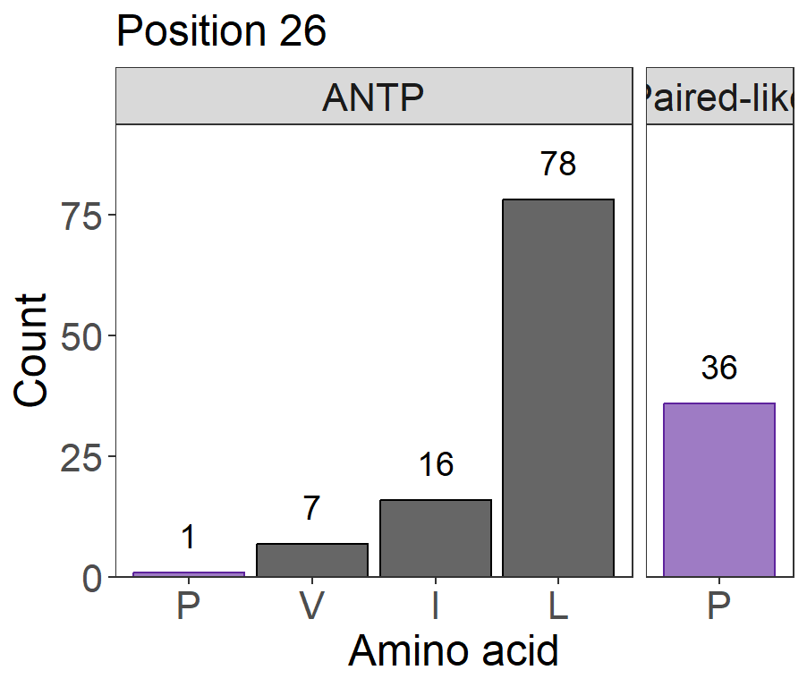

```r
residueDistribution(dfDBD, c("Paired-like", "ANTP"), 26)
```

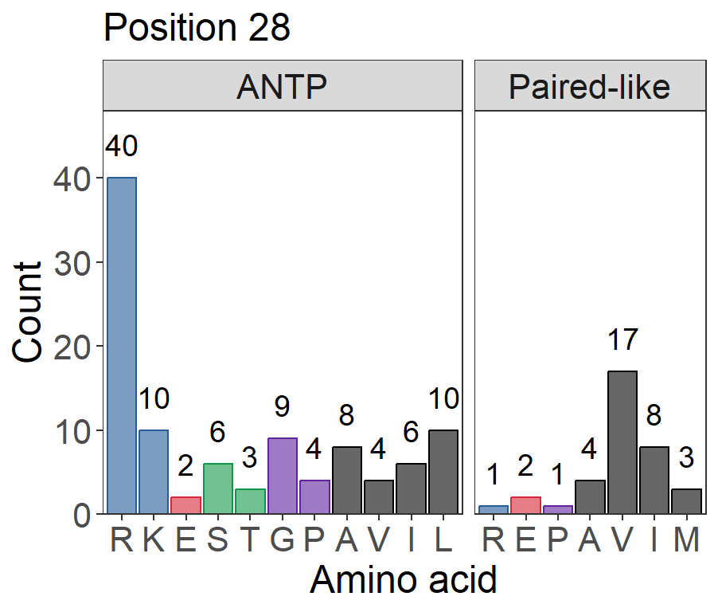

```r
residueDistribution(dfDBD, c("Paired-like", "ANTP"), 28)
```

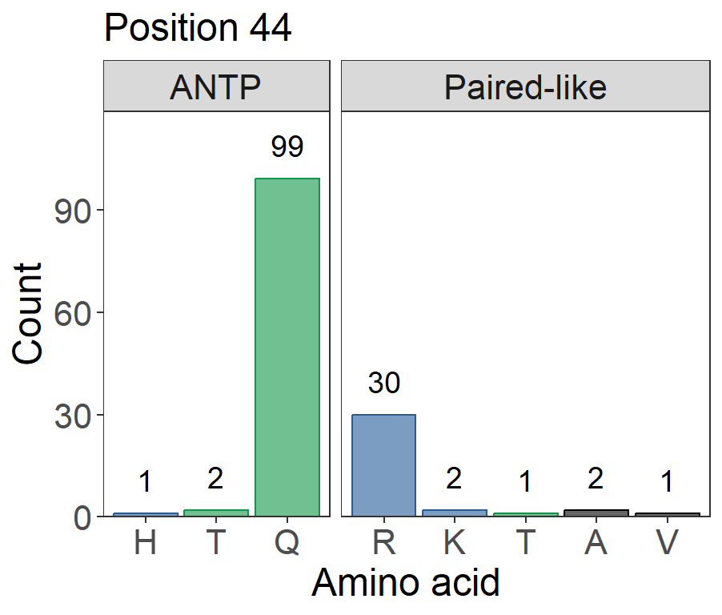

```r
residueDistribution(dfDBD, c("Paired-like", "ANTP"), 44)
```

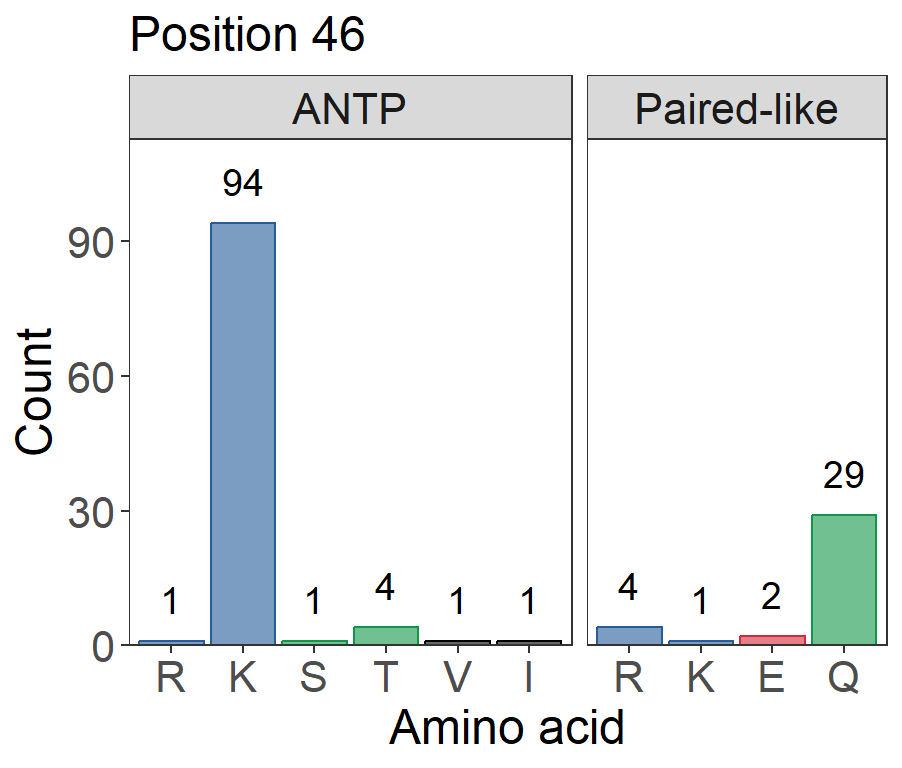

```r
residueDistribution(dfDBD, c("Paired-like", "ANTP"), 46)
```

# 4 Number of reasons ANTP cannot bind cooperatively to the P3 site

## 4.1 Version 1

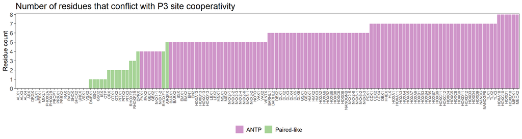

```r
conflictingResidues <-
  dfDBD %>%
  select(-seq) %>%
  filter(Class %in% c("ANTP", "Paired-like")) %>%
  mutate(R2 = str_sub(seqDBD, start = 2, end = 2) %>%
           str_detect(., "R")) %>%
  mutate(R3 = str_sub(seqDBD, start = 3, end = 3) %>%
           str_detect(., "R")) %>%
  mutate(pos_4 = str_sub(seqDBD, start = 4, end = 4) %>%
           str_detect(., "E", negate = TRUE)) %>%
  mutate(P26 = str_sub(seqDBD, start = 26, end = 26) %>%
           str_detect(., "P")) %>%
  mutate(pos_28 = str_sub(seqDBD, start = 28, end = 28) %>%
           str_detect(., "R", negate = TRUE)) %>%
  mutate(E32 = str_sub(seqDBD, start = 32, end = 32) %>%
           str_detect(., "E")) %>%
  mutate(E42 = str_sub(seqDBD, start = 42, end = 42) %>%
           str_detect(., "E")) %>%
  mutate(pos_43 = str_sub(seqDBD, start = 43, end = 43) %>%
           str_detect(., "R", negate = TRUE)) %>%
  mutate(R44 = str_sub(seqDBD, start = 44, end = 44) %>%
           str_detect(., "Q", negate = TRUE)) %>%
  mutate(Q46 = str_sub(seqDBD, start = 46, end = 46) %>%
           str_detect(., "R|K", negate = TRUE)) %>%
  mutate(pos50 = str_sub(seqDBD, start = 50, end = 50) %>%
           str_detect("K", negate = TRUE)) %>%
  pivot_longer(c(R2:pos50),
               names_to = "Residue",
               values_to = "Present") %>%
  group_by(TF, Class) %>%
  summarize(Count = sum(!Present)) %>%
  arrange(Count)

conflictingResidues %>%
  ggplot(aes(y = Count,
             x = reorder(TF, Count),
             fill = Class)) +
  geom_col(alpha = 0.5) +
  ylab("Residue count") +
  xlab("") +
  ggtitle("Number of residues that conflict with P3 site cooperativity") +
  scale_y_continuous(expand = c(0, 0),
                     limits = c(0, 8.1),
                     breaks = c(0:10)) +
  scale_fill_manual(values = c("#A02B93", "#4EA72E"),
                    name = "") +
  theme_bw() +
  theme(text = element_text(size = 15),
        panel.grid = element_blank(),
        axis.text.x = element_text(size = 8, angle = 90, vjust = 0.5, hjust = 1),
        axis.title.y = element_text(size = 13),
        legend.position = "bottom")
```

## 4.2 Version 2

**Changes**

- If DNA binding domain is identical between two proteins, they are represented by single column.
- Columns are shaded to represent whether broken rule contributes or is critical to cooperativity.

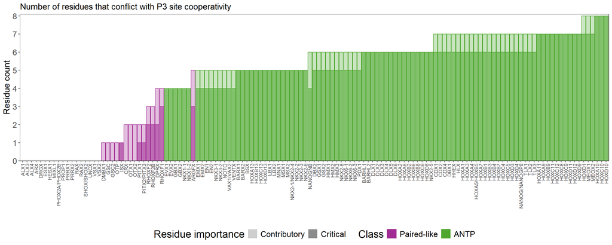

```r
dfDBDUnique <- dfDBD %>% filter(Class %in% c("ANTP", "Paired-like")) %>% distinct(., seqDBD, .keep_all = TRUE)
dfDBDMatching <- dfDBD %>% filter(Class %in% c("ANTP", "Paired-like")) %>% filter( !(TF %in% dfDBDUnique$TF) )

dfDBDConsolidated <- merge(dfDBDUnique, dfDBDMatching %>% select(TF, seqDBD), by = "seqDBD", all.x = TRUE) %>%
  mutate(label = case_when(is.na(TF.y) ~ TF.x, TRUE ~ paste(TF.x, "/", TF.y, sep = "")))



conflictingResidues <-
  dfDBDConsolidated %>%
  select(-seq) %>%
  filter(Class %in% c("ANTP", "Paired-like")) %>%
  mutate(R2 = str_sub(seqDBD, start = 2, end = 2) %>%
           str_detect(., "R")) %>%
  mutate(R3 = str_sub(seqDBD, start = 3, end = 3) %>%
           str_detect(., "R")) %>%
  mutate(pos_4 = str_sub(seqDBD, start = 4, end = 4) %>%
           str_detect(., "E", negate = TRUE)) %>%
  mutate(P26 = str_sub(seqDBD, start = 26, end = 26) %>%
           str_detect(., "P")) %>%
  mutate(pos_28 = str_sub(seqDBD, start = 28, end = 28) %>%
           str_detect(., "R", negate = TRUE)) %>%
  mutate(E32 = str_sub(seqDBD, start = 32, end = 32) %>%
           str_detect(., "E")) %>%
  mutate(E42 = str_sub(seqDBD, start = 42, end = 42) %>%
           str_detect(., "E")) %>%
  mutate(pos_43 = str_sub(seqDBD, start = 43, end = 43) %>%
           str_detect(., "R", negate = TRUE)) %>%
  mutate(R44 = str_sub(seqDBD, start = 44, end = 44) %>%
           str_detect(., "Q", negate = TRUE)) %>%
  mutate(Q46 = str_sub(seqDBD, start = 46, end = 46) %>%
           str_detect(., "R|K", negate = TRUE)) %>%
  mutate(pos50 = str_sub(seqDBD, start = 50, end = 50) %>%
           str_detect("K", negate = TRUE)) %>%
  pivot_longer(c(R2:pos50),
               names_to = "Residue",
               values_to = "Present") %>%
  mutate(RuleType = case_when(Residue %in% c("R2", "pos_4", "pos50") ~ "Contributory",
                              TRUE ~ "Critical")) %>%
  group_by(label, Class, RuleType) %>%
  summarize(Count = sum(!Present))


## BELOW CODE IS SO THAT I CAN ORDER BY RULE TYPE AS WELL AS NUMBER OF RULES BROKEN
TForder <- conflictingResidues  %>%
  pivot_wider(names_from = "RuleType",
              values_from = "Count",
              values_fill = 0) %>%
  mutate(Count = Contributory + Critical) %>%
  distinct() %>%
  arrange(Count, desc(Contributory)) %>%
  .$label

conflictingResidues %>%
  mutate(Class = factor(Class,
                        levels = c("Paired-like", "ANTP"),
                        ordered = TRUE)) %>%
  mutate(label = factor(label,
                        levels = TForder,
                        ordered = TRUE)) %>%
  ggplot(aes(y = Count,
             x = label,
             color = Class,
             fill = Class,
             alpha = RuleType)) +
  geom_col() +
  ylab("Residue count") +
  xlab("") +
  ggtitle("Number of residues that conflict with P3 site cooperativity") +
  scale_y_continuous(expand = c(0, 0),
                     limits = c(0, 8.1),
                     breaks = c(0:10)) +
  scale_fill_manual(values = c("#A02B93", "#4EA72E"),
                    name = "Class") +
  scale_color_manual(values = c("#A02B93", "#4EA72E"),
                     name = "Class") +
  scale_alpha_manual(values = c(0.3, 0.7),
                     name = "Residue importance") +
  theme_bw() +
  theme(text = element_text(size = 18),
        panel.grid = element_blank(),
        axis.text.x = element_text(size = 9, angle = 90, vjust = 0.5, hjust = 1),
        axis.title.y = element_text(size = 15),
        plot.title = element_text(size = 15),
        legend.position = "bottom")
```